# Recalling Words

### Background

Many teachers and other educators are interested in understanding how to best deliver new content to students. In general, they have two choices of how to do this.

1. The Meshed Approach
   - Deliver new content while simultaneously reviewing previously understood content.
2. The Before Approach
   - Deliver new content after fully reviewing previously understood content.

A study was performed to determine whether the *Meshed* or *Before* approaches to delivering content had any positive benefits on memory recall.

##### The Experiment (click to view)

### Are The Methods Equally as Effective?

We want to see if there is a meaningful difference in the performance of the data. Because the data sets are below n=30, and non-normally distributed[^1], we cannot use the central limit theorem, so a Wilcoxon test is most appropriate for the data. The null hypothesis is that the medians of the groups are the same, and the alternative hypothesis is that they are different.

Null Hypothesis (H0): $\mu_{SFR} = \mu_{Before} = \mu_{Meshed}$

Alternative Hypothesis (HA): $\mu_{SFR} \neq \mu_{Before} \neq \mu_{Meshed}$

### Data

Below are plots showing the data.

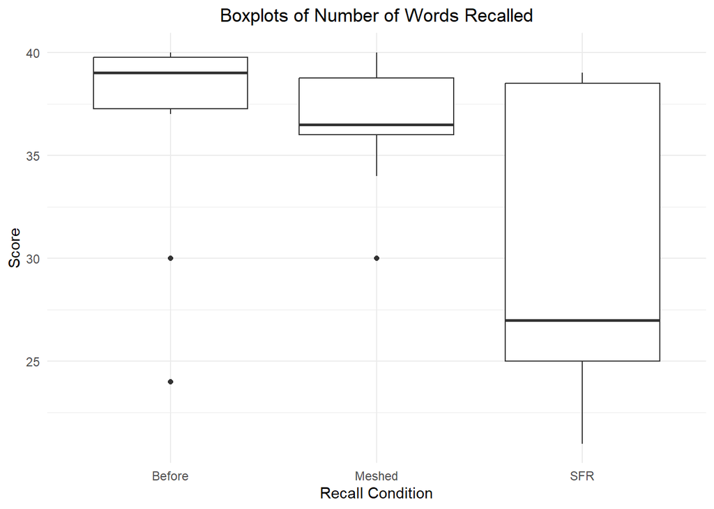

```r
SFR <- subset(Friendly, condition == "SFR")
Before <- subset(Friendly, condition == "Before")
Meshed <- subset(Friendly, condition == "Meshed")

# Combine all data into one data frame
friendly_data <- rbind(
  data.frame(condition = "SFR", correct = SFR$correct),
  data.frame(condition = "Before", correct = Before$correct),
  data.frame(condition = "Meshed", correct = Meshed$correct)
)

# Create the ggplot
ggplot(friendly_data, aes(x = condition, y = correct)) +
  geom_boxplot() +
  labs(title = "Boxplots of Number of Words Recalled",x="Recall Condition", y = "Score") +
  theme_minimal() +
  theme(plot.title = element_text(hjust = 0.5))
```

Just visually with the boxplots, we can see some outliers in the data.

Now let’s compare the groups with the Wilcoxon test.

### Running the Test

```r
SFR <- subset(Friendly, condition == "SFR")
Before <- subset(Friendly, condition == "Before")
Meshed <- subset(Friendly, condition == "Meshed")

# Comparing SFR vs Before
pander(wilcox.test(SFR$correct, Before$correct, paired = FALSE, alternative = "two.sided"))
```

Wilcoxon rank sum test with continuity correction: `SFR$correct` and `Before$correct`

| Test statistic | P value | Alternative hypothesis |
| --- | --- | --- |
| 23.5 | 0.04555 * | two.sided |

```r
# Comparing SFR vs Meshed
pander(wilcox.test(SFR$correct, Meshed$correct, paired = FALSE,alternative = "two.sided"))
```

Wilcoxon rank sum test with continuity correction: `SFR$correct` and `Meshed$correct`

| Test statistic | P value | Alternative hypothesis |
| --- | --- | --- |
| 28 | 0.1015 | two.sided |

```r
# Comparing Before vs Meshed
pander(wilcox.test(Before$correct, Meshed$correct, paired = FALSE,alternative = "two.sided"))
```

Wilcoxon rank sum test with continuity correction: `Before$correct` and `Meshed$correct`

| Test statistic | P value | Alternative hypothesis |
| --- | --- | --- |
| 62 | 0.378 | two.sided |

However, SFR and Meshed, and Before and Meshed both are statistically from the same population, at the p values .1015 and .378, respectively, so it can be said that while the Before condition is a statistically more effective method than the SFR method, the Meshed condition is not different from the Before. At an alpha of .0167, none of the methods are statistically different.

### Conclusion

At an alpha of .05, the Before condition is better than the SFR condition, but the Meshed condition is not statistically different from the other two.

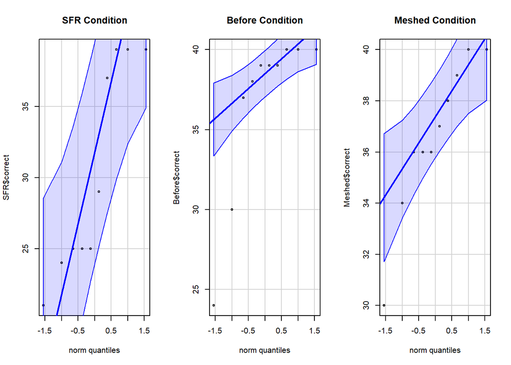

```r
SFR <- subset(Friendly, condition == "SFR")
Before <- subset(Friendly, condition == "Before")
Meshed <- subset(Friendly, condition == "Meshed")

# Set up the layout for side by side plots
par(mfrow=c(1, 3))

# Create qqplots
qqPlot(SFR$correct, main="SFR Condition",id=FALSE)
qqPlot(Before$correct, main="Before Condition",id=FALSE)
qqPlot(Meshed$correct, main="Meshed Condition",id=FALSE)
```